# Liste Rouge Régionale des poissons d’eau douce de Bretagne

Pré-traitements des données environnementales

OFB Bretagne

2024-08-13

# 1 Objectif : Dynamique de population des poissons d’eau douce de Bretagne

Script : 05_pre_traitements_donnees_env

Il s’agit de réaliser les pré-traitements des données environnementales utilisées pour l’étude. Cette étape permet notamment de détecter et de corriger les erreurs ou incohérences présentes dans le jeu de données relatives aux variables environnementales, contribuant ainsi à la mise en qualité des données.

# 2 Installation

## 2.1 Chargement des packages, fonctions et des données

```r
library(tidyverse)
library(aspe)
library(ggh4x)
library(zoo)
library(ggforce)  # Pour facet_grid2
```

```r
load(file = "../processed_data/selection_pop_ope.rda")
rdata_tables <- misc_nom_dernier_fichier(
  repertoire = "../../../../projets/ASPE/raw_data/rdata",
  pattern = "^tables")
load(rdata_tables)
```

# 3 Constitution du jeu de données

## 3.1 Création du jeu de données *ope_selection_param_env*

Création d’un dataframe contenant les variables environnementales relatives aux opérations contenues dans la passerelle (cf Script 00_selection_pop_ope).

```r
ope_selection_param_env <- passerelle %>%  # Création du dataframe à partir de la passerelle
  select(-lop_id,
         -pre_id) %>%
  mef_ajouter_ope_env() %>%  # Ajout des données environnementales
  mef_ajouter_ope_date() %>%
  select(-ope_date,
         -sta_id,
         -distance_mer,
         -obj_libelle,
         -obj_id)%>%
  distinct() %>%
  pivot_longer(altitude:temp_janvier,
               names_to = "parametre",
               values_to= "valeur") %>%
  distinct()
```

## 3.2 Gestion des *NA*

Les données manquantes (*NA*) sont isolées dans un jeu de données extérieur afin de rassembler et de les identifier. L’ensemble des données environnementales sont ensuite triées par paramètres et par années. Les *NA* sont remplacés par les médianes des données *n-1* et *n+1* entourant la valeur manquante (relative à la station / point de prélèvement).

```r
valeur_na <- ope_selection_param_env %>% # Les NA sont rassemblés dans le dataframe valeur_na
  filter(if_any(everything(), is.na))

ope_selection_param_env <- ope_selection_param_env %>%
  arrange(parametre, annee) %>%
  group_by(parametre, pop_id) %>%
  mutate(valeur = ifelse(is.na(valeur),
                         na.aggregate(valeur, function(x) {# Appliquer la médiane sur une fenêtre définie
                           zoo::rollapply(x, width = 3, FUN = median, fill = NA, align = "center", na.rm = TRUE)}),
                         valeur)) %>%
  ungroup()
```

## 3.3 Gestion des valeurs aberrantes

*Étape 1* : Identification des valeurs aberrantes d’une part et des valeurs jugées **très aberrantes** d’autre part :

```r
ope_selection_param_env <- ope_selection_param_env %>%
  group_by(parametre,
           pop_id) %>%
  mutate(Q1 = quantile(valeur, 0.25, na.rm = TRUE),
         Q3 = quantile(valeur, 0.75, na.rm = TRUE),
         IQR = Q3 - Q1,
         lower_bound = Q1 - 1.5 * IQR,
         upper_bound = Q3 + 1.5 * IQR,
         very_aberrant = valeur < Q1 - 2.5 * IQR | valeur > Q3 + 2.5 * IQR,
         aberrant = valeur < lower_bound | valeur > upper_bound,
         median_val = median(valeur, na.rm = TRUE)) %>%
  ungroup()
```

### 3.3.1 Représentation graphique

Nous réalisons une représentation graphique permettant de remarquer facilement les valeurs abérantes du jeu de données (elles apparaissent en rouge à titre indicatif). Il s’agit de représenter toutes les valeurs des paramètres, par année, et par station. Une fois identifiées, les erreurs sont à corriger sur la base *aspe*.

*Étape 2* : Visualisation des valeurs aberrantes (en orange) et les valeurs très aberrantes (en rouge) :

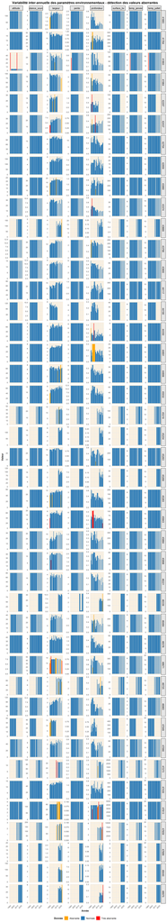

```r
ope_selection_param_env <- ope_selection_param_env %>%
  mutate(aberrant_color = case_when(
    very_aberrant ~ "Très aberrante",
    aberrant ~ "Aberrante",
    TRUE ~ "Normale"
  ))

donnees_env_aberrantes <- ggplot(ope_selection_param_env, aes(x = annee, y = valeur, fill = aberrant_color)) +
  geom_bar(stat = "identity") +
  scale_fill_manual(values = c("Normale" = "#2C7BB6", "Aberrante" = "orange", "Très aberrante" = "red")) +
  facet_grid2(~ pop_id ~ parametre,
              scales = "free_y",
              independent = "y") +
  labs(title = "Variabilité inter-annuelle des paramètres environnementaux - détection des valeurs aberrantes",
       x = "Année",
       y = "Valeur",
       fill = "Donnée") +
  theme_minimal(base_size = 12) +
  theme(panel.background = element_rect(fill = "#faf0e0", color = NA),
        strip.background = element_rect(fill = "grey90"),
        strip.text = element_text(size = 10, color = "black"),
        axis.text.x = element_text(angle = 45, hjust = 1, size = 8),
        axis.text.y = element_text(size = 8),
        axis.title = element_text(size = 10, face = "bold"),
        plot.title = element_text(size = 14, face = "bold", hjust = 0.5),
        legend.position = "bottom",
        legend.title = element_text(size = 10, face = "bold"))

# Afficher le graphique
print(donnees_env_aberrantes)
```

Les erreurs ainsi identifiées doivent être corrigées au sein de la base *aspe*. De manière temporaire, on remplace les valeurs très aberrantes susceptibles d’influencer les futures analyses, par des valeurs médianes.

*Étape 3* : Remplacer les valeurs très aberrantes par la médiane des années *n-1* et *n+1* du paramètre.

```r
ope_selection_param_env <- ope_selection_param_env %>%
  arrange(parametre, pop_id, annee) %>%
  group_by(parametre, pop_id) %>%
mutate(valeur = ifelse(very_aberrant,
                         ifelse(is.na(lag(valeur)) & !is.na(lead(valeur)), lead(valeur),
                                ifelse(is.na(lead(valeur)) & !is.na(lag(valeur)), lag(valeur),
                                       zoo::rollapply(valeur, width = 3, FUN = function(x) median(x, na.rm = TRUE), fill = NA, align = "center"))),
                         valeur)) %>%
  ungroup() %>%
  select(-Q1, -Q3, -IQR, -lower_bound, -upper_bound, -median_val, -very_aberrant, - aberrant, - aberrant_color)
```

# 4 Sauvegarde

Nous sauvegardons dans un fichier .rda le jeu de données *ope_selection_param_env* qui nous servira pour des analyses futures.

```r
save(ope_selection_param_env,
     file = "../processed_data/pre_traitements_donnees_env.rda")
```

# 5 Référence bibliographique

Irz, P., Mondy, C., Richard, B. Bonnafoux, L. (2024). aspe: An R package to analyse and visualise river fish data in France. R package version 0.4.1, https://github.com/PascalIrz/aspe/